# rumina_hiv

Stephanie Goya

2025-08-29

```r
umi10pcr7er05 <- read.csv("./umi10pcr7er05_ivar.csv", row.names=1)

#create variant ID
umi10pcr7er05$variant <- paste0(umi10pcr7er05$REF, umi10pcr7er05$POS, umi10pcr7er05$ALT)
```

Simulation of HIV population with UMI of 10nt, with 0.5% error rate, and 7 PCR amplification cycles. Below is the comparison of SNV detection when the ground truth in 30,000 sequence templates is: 0.01% freq (3 templates) A176G T250A C413T 0.1% freq (30 templates) A527C T574C T795A 1% freq (300 templates) A747G A852G C714A

FP= false positives, FN= false negatives, and TP= true positives were calculated per replicate (three replicates in total) and then precision, recall and F1 score were calculated using average F1 score: if F1 = 1 precision and recall are perfect, if F1 = 0 total fail detecting real positves

```r
#ground truth variants and expected frequencies
true_variants <- c("A176G", "A527C", "A747G", "A852G", "C413T", "C714A", "T250A", "T574C", "T795A")

umi10pcr7er05_summary_by_replicate <- umi10pcr7er05 %>%
  group_by(tool, replicate) %>%
  summarise(
    TP = sum(variant %in% true_variants),
    FP = sum(!(variant %in% true_variants)),
    FN = length(true_variants) - TP,
    Precision = TP / (TP + FP),
    Recall = TP / (TP + FN),
    F1 = 2 * Precision * Recall / (Precision + Recall),
    .groups = "drop"
  )

umi10pcr7er05_metrics_summary <- umi10pcr7er05_summary_by_replicate %>%
  group_by(tool) %>%
  summarise(
    mean_Precision = mean(Precision),
    sd_Precision = sd(Precision),
    mean_Recall = mean(Recall),
    sd_Recall = sd(Recall),
    mean_F1 = mean(F1),
    sd_F1 = sd(F1),
    .groups = "drop"
  )

umi10pcr7er05_metrics_summary
```

```
## # A tibble: 7 × 7
##   tool         mean_Precision sd_Precision mean_Recall sd_Recall mean_F1   sd_F1
##   <chr>                 <dbl>        <dbl>       <dbl>     <dbl>   <dbl>   <dbl>
## 1 RUMINA-sing…        0.0103    0.000565         0.963    0.0642 0.0205  1.11e-3
## 2 RUMINA_acyc…        0.867     0.0577           0.963    0.0642 0.912   6.08e-2
## 3 RUMINA_dire…        1         0                0.963    0.0642 0.980   3.40e-2
## 4 RUMINA_nole…        1         0                0.963    0.0642 0.980   3.40e-2
## 5 RUMINA_raw          0.0733    0.00217          0.963    0.0642 0.136   3.62e-3
## 6 UMI-tools           0.00304   0.00000802       1        0      0.00606 1.59e-5
## 7 UMICollapse         0.00307   0.0000189        1        0      0.00613 3.76e-5
```

```r
# Ground truth variants
true_variants <- c("A176G", "A527C", "A747G", "A852G",
                   "C413T", "C714A", "T250A", "T574C", "T795A")

# Consenso: mantener variantes detectadas en >= 2 replicados
umi10pcr7er05_consensus <- umi10pcr7er05 %>%
  group_by(tool, variant) %>%
  summarise(n_reps = n_distinct(replicate), .groups = "drop") %>%
  filter(n_reps >= 2)

# Evaluar métricas por tool
umi10pcr7er05_metrics_consensus <- umi10pcr7er05_consensus %>%
  group_by(tool) %>%
  summarise(
    TP = sum(variant %in% true_variants),
    FP = sum(!(variant %in% true_variants)),
    FN = length(true_variants) - TP,
    Precision = TP / (TP + FP),
    Recall = TP / (TP + FN),
    F1 = ifelse((Precision + Recall) == 0, 0,
                2 * Precision * Recall / (Precision + Recall)),
    .groups = "drop"
  )

umi10pcr7er05_metrics_consensus
```

```
## # A tibble: 7 × 7
##   tool                  TP    FP    FN Precision Recall      F1
##   <chr>              <int> <int> <int>     <dbl>  <dbl>   <dbl>
## 1 RUMINA-singletons      9   593     0   0.0150       1 0.0295
## 2 RUMINA_acyclic         9     0     0   1            1 1
## 3 RUMINA_directional     9     0     0   1            1 1
## 4 RUMINA_nolength        9     0     0   1            1 1
## 5 RUMINA_raw             9     8     0   0.529        1 0.692
## 6 UMI-tools              9  2995     0   0.00300      1 0.00597
## 7 UMICollapse            9  2981     0   0.00301      1 0.00600
```

```r
true_freqs <- data.frame(
  variant = c("A176G", "A527C", "A747G", "A852G", "C413T", "C714A", "T250A", "T574C", "T795A"),
  simulated_freq = c(0.0001, 0.001, 0.01, 0.01, 0.0001, 0.01, 0.0001, 0.001, 0.001)
) %>%
  mutate(freq_label = factor(simulated_freq,
                             levels = c(0.0001, 0.001, 0.01),
                             labels = c("0.01%", "0.1%", "1%")))
```

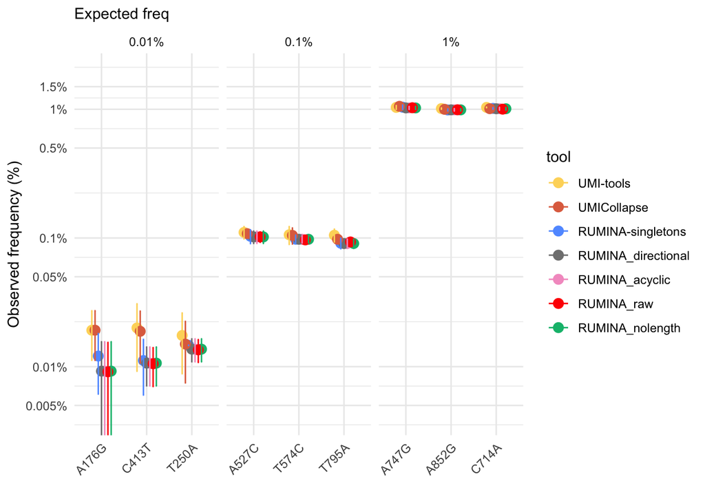

```r
#observed frequencies
ivar_tp <- umi10pcr7er05 %>%
  filter(variant %in% true_freqs$variant)

observed_freqs_by_rep <- ivar_tp %>%
  group_by(tool, variant, replicate) %>%
  summarise(observed_freqs = mean(ALT_FREQ), .groups = 'drop')

#combine freq observed with expected freq
freq_comparacion <- left_join(observed_freqs_by_rep, true_freqs, by = "variant")

freq_summary <- freq_comparacion %>%
  group_by(tool, variant, simulated_freq, freq_label) %>%
  summarise(
    mean_observed = mean(observed_freqs),
    sd_observed = sd(observed_freqs),
    .groups = "drop"
  )

#plot observed vs expected freq
freq_summary$tool <- factor(freq_summary$tool, levels = c(
  "UMI-tools",
  "UMICollapse",
  "RUMINA-singletons",
  "RUMINA_directional",
  "RUMINA_acyclic",
  "RUMINA_raw",
  "RUMINA_nolength"
))

truepositives <- ggplot(freq_summary, aes(x = variant, y = mean_observed, color = tool)) +
  geom_point(position = position_dodge(width = 0.5), size = 3) +
  geom_errorbar(aes(ymin = mean_observed - sd_observed,
                    ymax = mean_observed + sd_observed),
                position = position_dodge(width = 0.5),
                width = 0.2) +
  scale_y_log10(breaks = c(0.00005, 0.0001, 0.0005, 0.001, 0.005, 0.01, 0.015),
                labels = c("0.005%", "0.01%", "0.05%", "0.1%", "0.5%", "1%", "1.5%")) +
  facet_wrap(~freq_label, scales = "free_x") +
  labs(subtitle = "Expected freq", x= "", y = "Observed frequency (%)") +
  theme_minimal() +
  theme(axis.text.x = element_text(angle = 45, hjust = 1)) +
  coord_cartesian(ylim = c(0.00004, 0.02)) +
  scale_color_manual(values = c(
    "UMI-tools" = "#fdd768",              # Yellow
    "UMICollapse" = "#e06f4f",            # Orange
    "RUMINA-singletons" = "#619cff",       # Blue
    "RUMINA_directional" = "#808080",     # Gray
    "RUMINA_acyclic" = "#f49dc9",         # Pink
    "RUMINA_raw" = "red",             # Red
    "RUMINA_nolength" = "#00bb7b"      # Green
  ))

print(truepositives)
```

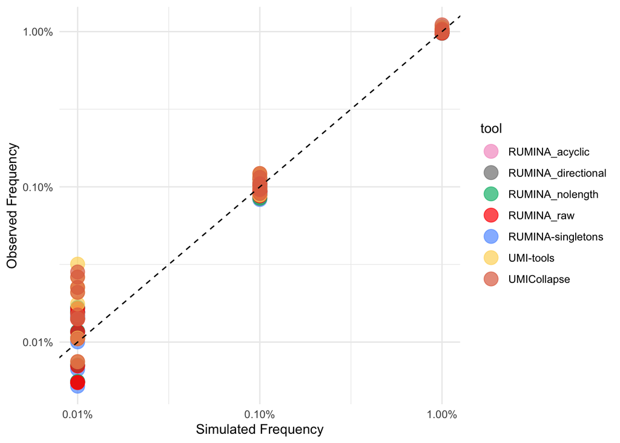

[figure not shown]

[figure not shown]

[output not shown]

[figure not shown]

[figure not shown]

```r
#correlation plot
coorrelation_TP <- ggplot(freq_comparacion, aes(x = simulated_freq, y = observed_freqs, color = tool)) +
  geom_point(size = 5, alpha = 0.7) +
  geom_abline(slope = 1, intercept = 0, linetype = "dashed") +
  scale_x_log10(labels = scales::percent_format(accuracy = 0.01)) +
  scale_y_log10(labels = scales::percent_format(accuracy = 0.01)) +
  labs(x = "Simulated Frequency",
       y = "Observed Frequency") +
  theme_minimal() +
  scale_color_manual(values = c(
    "UMI-tools" = "#fdd768",              # Yellow
    "UMICollapse" = "#e06f4f",            # Orange
    "RUMINA-singletons" = "#619cff",       # Blue
    "RUMINA_directional" = "#808080",     # Gray
    "RUMINA_acyclic" = "#f49dc9",         # Pink
    "RUMINA_raw" = "red",             # Red
    "RUMINA_nolength" = "#00bb7b"      # Green
  ))

print(coorrelation_TP)
```

```r
#count FP per tool per replicate
fp_counts <- umi10pcr7er05 %>%
  filter(!(variant %in% true_freqs$variant)) %>%
  group_by(tool, replicate) %>%
  summarise(n_fp = n(), .groups = "drop")

fp_summary <- fp_counts %>%
  group_by(tool) %>%
  summarise(
    mean_fp = mean(n_fp),
    sd_fp = sd(n_fp),
    .groups = "drop"
  )

print(fp_summary)
```

```
## # A tibble: 5 × 3
##   tool              mean_fp  sd_fp
##   <chr>               <dbl>  <dbl>
## 1 RUMINA-singletons  829.   52.5
## 2 RUMINA_acyclic       1.33  0.577
## 3 RUMINA_raw         110.    9.07
## 4 UMI-tools         2954     7.81
## 5 UMICollapse       2919.   18.0
```

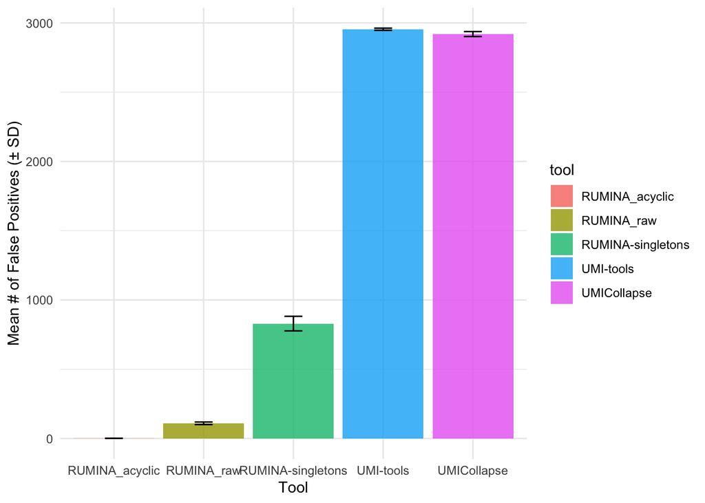

```r
#variability per replicate
fp_barplot <- ggplot(fp_summary, aes(x = tool, y = mean_fp, fill = tool)) +
  geom_bar(stat = "identity", alpha = 0.8) +
  geom_errorbar(aes(ymin = mean_fp - sd_fp, ymax = mean_fp + sd_fp),
                width = 0.2) +
  labs(x = "Tool", y = "Mean # of False Positives (± SD)") +
  theme_minimal()

fp_barplot
```

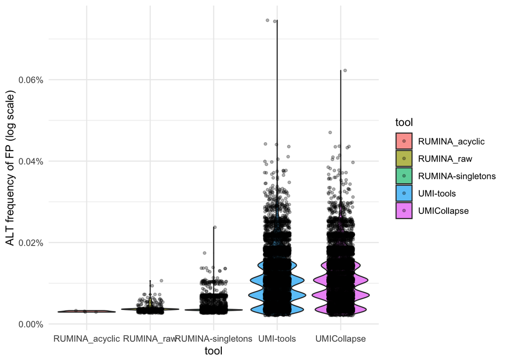

```r
#violin plot
freq_fp_hist <- umi10pcr7er05 %>%
  filter(!(variant %in% true_freqs$variant))

violin_FP <- ggplot(freq_fp_hist,
  aes(x = tool, y = ALT_FREQ, fill = tool)) +
  geom_violin(alpha = 0.7, scale = "width", trim = TRUE) +
  geom_jitter(width = 0.2, alpha = 0.3, size = 1) +
  scale_y_continuous(labels = scales::percent_format(accuracy = 0.01)) +
  labs(y = "ALT frequency of FP (log scale)") +
  theme_minimal()

 violin_FP
```

```r
#violin plot per replicate
 umi10pcr7er05$tool <- factor(umi10pcr7er05$tool, levels = c(
  "UMI-tools",
  "UMICollapse",
  "RUMINA-singletons",
  "RUMINA_directional",
  "RUMINA_acyclic",
  "RUMINA_raw",
  "RUMINA_nolength"
))

violin_FP_replicate <- umi10pcr7er05 %>%
  filter(!(variant %in% true_freqs$variant)) %>%
  ggplot(aes(x = tool, y = ALT_FREQ)) +

  # Jitter con color por tool
  geom_jitter(aes(color = tool), width = 0.2, alpha = 0.3, size = 1) +

  # Violin gris, sin relación con tool
  geom_violin(fill = "lightgray", alpha = 0.5, scale = "width", trim = TRUE) +

  scale_y_continuous(labels = scales::percent_format(accuracy = 0.01)) +
  facet_wrap(~ replicate) +
  labs(y = "ALT Freq") +
  theme_classic() +

  # Colores personalizados para los puntos (color)
  scale_color_manual(values = c(
    "UMI-tools" = "#fdd768",              # Yellow
    "UMICollapse" = "#e06f4f",            # Orange
    "RUMINA-singletons" = "#619cff",       # Blue
    "RUMINA_directional" = "#808080",     # Gray
    "RUMINA_acyclic" = "#f49dc9",         # Pink
    "RUMINA_raw" = "red",             # Red
    "RUMINA_nolength" = "#00bb7b"      # Green
  ))
```

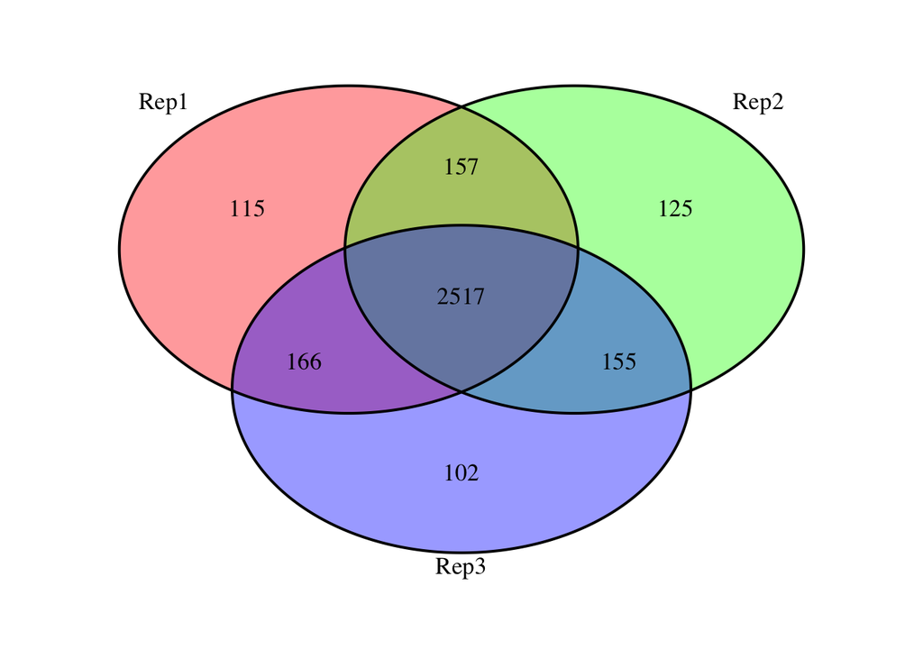

```r
fp_list_replicas_umitools <- list(
  Rep1 = umi10pcr7er05 %>% filter(tool == "UMI-tools", replicate == "s31", !(variant %in% true_freqs$variant)) %>% pull(variant) %>% unique(),
  Rep2 = umi10pcr7er05 %>% filter(tool == "UMI-tools", replicate == "s42", !(variant %in% true_freqs$variant)) %>% pull(variant) %>% unique(),
  Rep3 = umi10pcr7er05 %>% filter(tool == "UMI-tools", replicate == "s53", !(variant %in% true_freqs$variant)) %>% pull(variant) %>% unique()
)

venn.plot_umitools <- venn.diagram(
  x = fp_list_replicas_umitools,
  filename = NULL,
  fill = c("red", "green", "blue"),
  alpha = 0.4,
  cex = 1.1,
  cat.cex = 1.1,
  margin = 0.1
)

grid::grid.newpage()
grid::grid.draw(venn.plot_umitools)
```

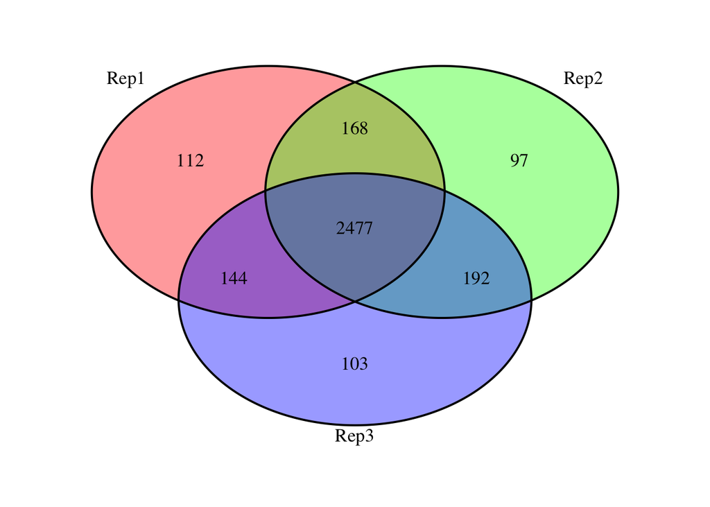

```r
fp_list_replicas_umicollapse <- list(
  Rep1 = umi10pcr7er05 %>% filter(tool == "UMICollapse", replicate == "s31", !(variant %in% true_freqs$variant)) %>% pull(variant) %>% unique(),
  Rep2 = umi10pcr7er05 %>% filter(tool == "UMICollapse", replicate == "s42", !(variant %in% true_freqs$variant)) %>% pull(variant) %>% unique(),
  Rep3 = umi10pcr7er05 %>% filter(tool == "UMICollapse", replicate == "s53", !(variant %in% true_freqs$variant)) %>% pull(variant) %>% unique()
)

venn.plot_umicollapse <- venn.diagram(
  x = fp_list_replicas_umicollapse,
  filename = NULL,
  fill = c("red", "green", "blue"),
  alpha = 0.4,
  cex = 1.1,
  cat.cex = 1.1,
  margin = 0.1
)

grid::grid.newpage()
grid::grid.draw(venn.plot_umicollapse)
```

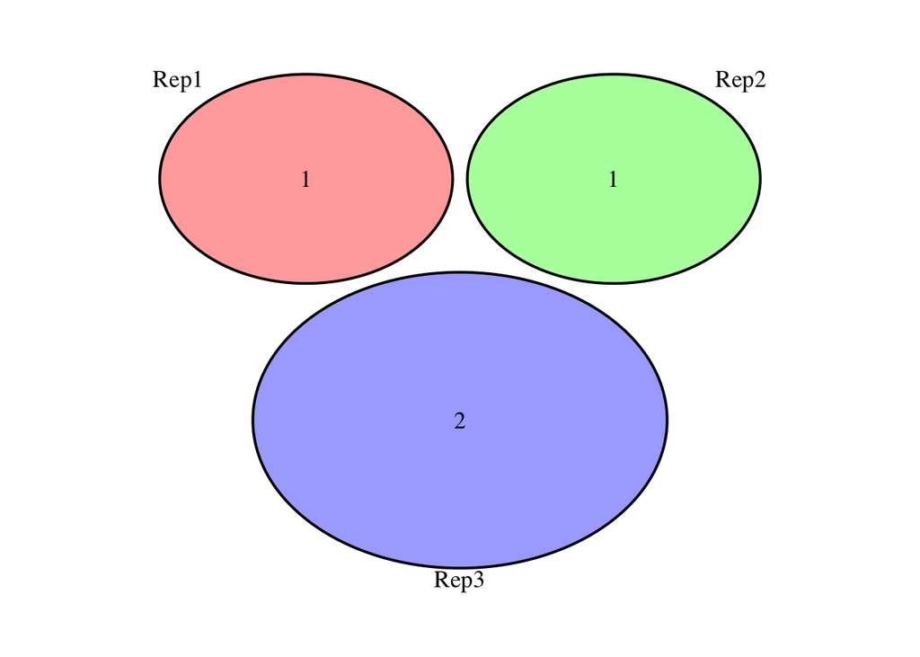

```r
fp_list_replicas_rumacyclic <- list(
  Rep1 = umi10pcr7er05 %>% filter(tool == "RUMINA_acyclic", replicate == "s31", !(variant %in% true_freqs$variant)) %>% pull(variant) %>% unique(),
  Rep2 = umi10pcr7er05 %>% filter(tool == "RUMINA_acyclic", replicate == "s42", !(variant %in% true_freqs$variant)) %>% pull(variant) %>% unique(),
  Rep3 = umi10pcr7er05 %>% filter(tool == "RUMINA_acyclic", replicate == "s53", !(variant %in% true_freqs$variant)) %>% pull(variant) %>% unique()
)

venn.plot_rumacyclic <- venn.diagram(
  x = fp_list_replicas_rumacyclic,
  filename = NULL,
  fill = c("red", "green", "blue"),
  alpha = 0.4,
  cex = 1.1,
  cat.cex = 1.1,
  margin = 0.1
)

grid::grid.newpage()
grid::grid.draw(venn.plot_rumacyclic)
```

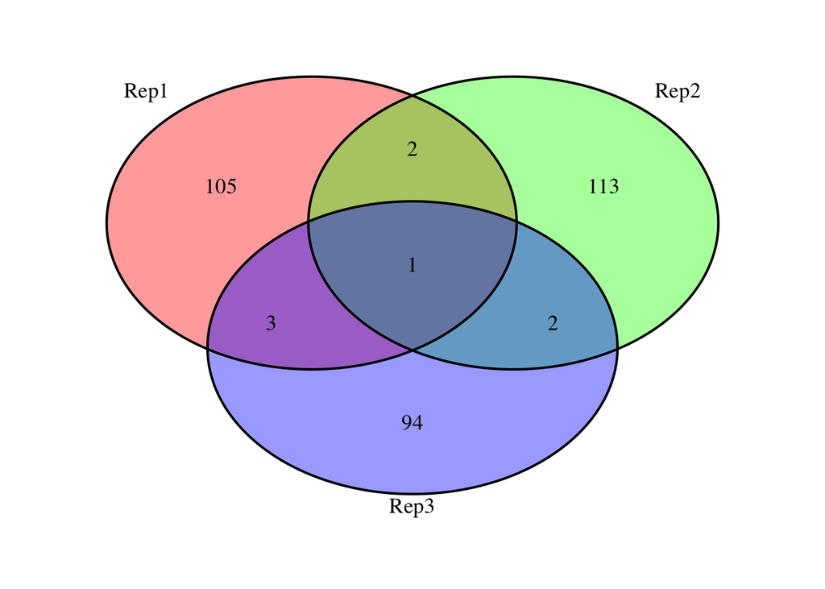

```r
fp_list_replicas_rumraw <- list(
  Rep1 = umi10pcr7er05 %>% filter(tool == "RUMINA_raw", replicate == "s31", !(variant %in% true_freqs$variant)) %>% pull(variant) %>% unique(),
  Rep2 = umi10pcr7er05 %>% filter(tool == "RUMINA_raw", replicate == "s42", !(variant %in% true_freqs$variant)) %>% pull(variant) %>% unique(),
  Rep3 = umi10pcr7er05 %>% filter(tool == "RUMINA_raw", replicate == "s53", !(variant %in% true_freqs$variant)) %>% pull(variant) %>% unique()
)

venn.plot_rumraw <- venn.diagram(
  x = fp_list_replicas_rumraw,
  filename = NULL,
  fill = c("red", "green", "blue"),
  alpha = 0.4,
  cex = 1.1,
  cat.cex = 1.1,
  margin = 0.1
)

grid::grid.newpage()
grid::grid.draw(venn.plot_rumraw)
```

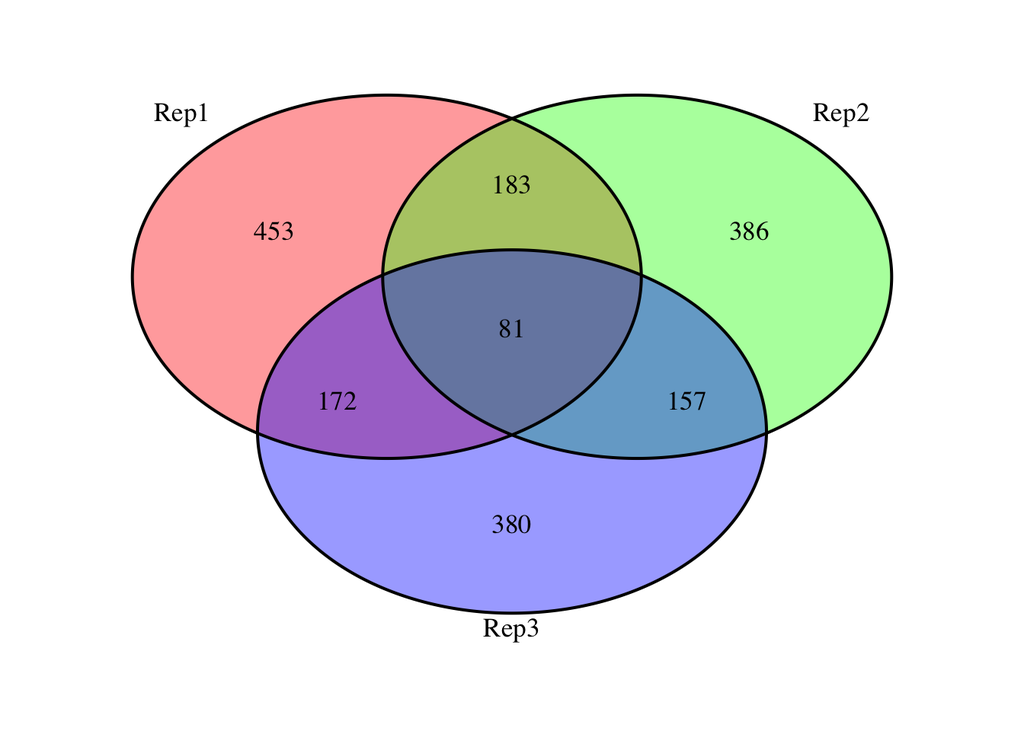

```r
fp_list_replicas_rumsing <- list(
  Rep1 = umi10pcr7er05 %>% filter(tool == "RUMINA-singletons", replicate == "s31", !(variant %in% true_freqs$variant)) %>% pull(variant) %>% unique(),
  Rep2 = umi10pcr7er05 %>% filter(tool == "RUMINA-singletons", replicate == "s42", !(variant %in% true_freqs$variant)) %>% pull(variant) %>% unique(),
  Rep3 = umi10pcr7er05 %>% filter(tool == "RUMINA-singletons", replicate == "s53", !(variant %in% true_freqs$variant)) %>% pull(variant) %>% unique()
)

venn.plot_rumsing <- venn.diagram(
  x = fp_list_replicas_rumsing,
  filename = NULL,
  fill = c("red", "green", "blue"),
  alpha = 0.4,
  cex = 1.1,
  cat.cex = 1.1,
  margin = 0.1
)

grid::grid.newpage()
grid::grid.draw(venn.plot_rumsing)
```

```r
# FP consensuados (presentes en >= 2 replicados) para cada tool
fp_consensus_umitools <- fp_list_replicas_umitools %>%
  unlist() %>%
  table() %>%
  .[. >= 2] %>%
  names()

fp_consensus_umicollapse <- fp_list_replicas_umicollapse %>%
  unlist() %>%
  table() %>%
  .[. >= 2] %>%
  names()

# Intersección (FP compartidos por ambas herramientas en >=2 réplicas)
fp_shared <- intersect(fp_consensus_umitools, fp_consensus_umicollapse)

# Exclusivos de cada herramienta
fp_only_umitools   <- setdiff(fp_consensus_umitools, fp_consensus_umicollapse)
fp_only_umicollapse <- setdiff(fp_consensus_umicollapse, fp_consensus_umitools)

# Conteo rápido
length(fp_shared)
```

```
## [1] 2917
```

```r
length(fp_only_umitools)
```

```
## [1] 78
```

```r
length(fp_only_umicollapse)
```

```
## [1] 64
```

```r
library(VennDiagram)

venn_tools <- venn.diagram(
  x = list(
    UMItools = fp_consensus_umitools,
    UMICollapse = fp_consensus_umicollapse
  ),
  filename = NULL,
  fill = c("red", "blue"),
  alpha = 0.4,
  cex = 1.2,
  cat.cex = 1.2,
  margin = 0.1
)

grid::grid.newpage()
grid::grid.draw(venn_tools)
```

[figure not shown]

```
UMI10_ER05_PCR7 <- read.csv("./umi10pcr7er05_ivar.csv", row.names=1)
UMI10_ER05_PCR7$variant <- paste0(UMI10_ER05_PCR7$REF, UMI10_ER05_PCR7$POS, UMI10_ER05_PCR7$ALT)

UMI8_ER05_PCR7 <- read.csv("./UMI8_ivar.csv", row.names=1)
UMI8_ER05_PCR7$variant <- paste0(UMI8_ER05_PCR7$REF, UMI8_ER05_PCR7$POS, UMI8_ER05_PCR7$ALT)

UMI12_ER05_PCR7 <- read.csv("./UMI12_ivar.csv", row.names=1)
UMI12_ER05_PCR7$variant <- paste0(UMI12_ER05_PCR7$REF, UMI12_ER05_PCR7$POS, UMI12_ER05_PCR7$ALT)

UMI10_ER05_PCR10 <- read.csv("./PCR10_6M_ivar.csv", row.names=1)
UMI10_ER05_PCR10$variant <- paste0(UMI10_ER05_PCR10$REF, UMI10_ER05_PCR10$POS, UMI10_ER05_PCR10$ALT)

UMI10_ER05_PCR13 <- read.csv("./PCR13_6M_ivar.csv", row.names=1)
UMI10_ER05_PCR13$variant <- paste0(UMI10_ER05_PCR13$REF, UMI10_ER05_PCR13$POS, UMI10_ER05_PCR13$ALT)

UMI10_ER01_PCR7 <- read.csv("./ER01_ivar.csv", row.names=1)
UMI10_ER01_PCR7$variant <- paste0(UMI10_ER01_PCR7$REF, UMI10_ER01_PCR7$POS, UMI10_ER01_PCR7$ALT)

UMI10_ER1_PCR7 <- read.csv("./ER1_ivar.csv", row.names=1)
UMI10_ER1_PCR7$variant <- paste0(UMI10_ER1_PCR7$REF, UMI10_ER1_PCR7$POS, UMI10_ER1_PCR7$ALT)
```

Different simulation conditions from the one that was tested before (UMI10_ER05_PCR7), but changed to: UMI lenght 8nt (UMI8_ER05_PCR7) or 12 nt (UMI12_ER05_PCR7) PCR amplification of 10 cycles (UMI10_ER05_PCR10) or 13 cycles (UMI10_ER05_PCR13) UMI error rate of 0.1% (UMI10_ER01_PCR7) or 1% (UMI10_ER1_PCR7)

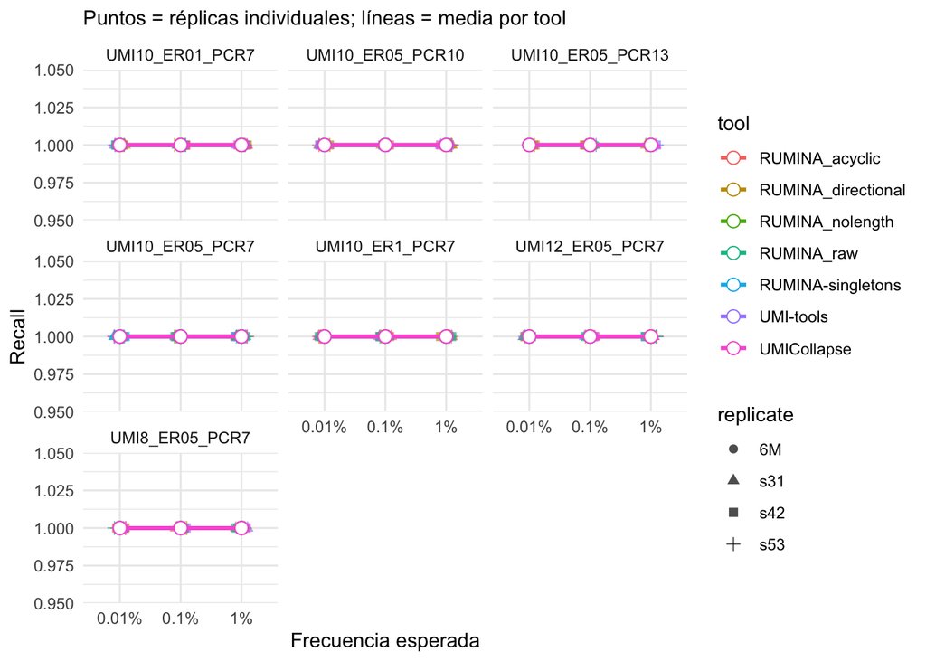

```r
all_conditions <- list(
  UMI10_ER05_PCR7 = UMI10_ER05_PCR7,
  UMI8_ER05_PCR7 = UMI8_ER05_PCR7,
  UMI12_ER05_PCR7 = UMI12_ER05_PCR7,
  UMI10_ER05_PCR10 = UMI10_ER05_PCR10,
  UMI10_ER05_PCR13 = UMI10_ER05_PCR13,
  UMI10_ER01_PCR7 = UMI10_ER01_PCR7,
  UMI10_ER1_PCR7 = UMI10_ER1_PCR7
)

#analysis per tool per condition
evaluate_df <- function(df, tool, condition) {
  called <- df %>% distinct(variant, replicate)

  eval <- true_freqs %>%
    crossing(replicate = unique(df$replicate)) %>%
    left_join(called, by = c("variant", "replicate")) %>%
    mutate(detected = !is.na(replicate)) %>%
    group_by(freq_label, replicate) %>%
    summarise(
      TP = sum(detected),
      FN = sum(!detected),
      .groups = "drop"
    ) %>%
    mutate(tool = tool, condition = condition)

#FP per replicate
  fp_per_replicate <- df %>%
    filter(!(variant %in% true_freqs$variant)) %>%
    group_by(replicate) %>%
    summarise(FP = n(), .groups = "drop")

  eval <- eval %>%
    left_join(fp_per_replicate, by = "replicate") %>%
    mutate(FP = ifelse(is.na(FP), 0, FP)) %>%
    mutate(
      Precision = TP / (TP + FP),
      Recall = TP / (TP + FN),
      F1 = ifelse((Precision + Recall) == 0, 0, 2 * Precision * Recall / (Precision + Recall))
    )

  return(eval)
}

#run for all conditions per tools
results_all <- map_dfr(names(all_conditions), function(cond_name) {
  df_cond <- all_conditions[[cond_name]]

  tools <- unique(df_cond$tool)

  map_dfr(tools, function(tool_name) {
    df_tool <- df_cond %>% filter(tool == tool_name)
    evaluate_df(df_tool, tool = tool_name, condition = cond_name)
  })
})

#plotting recall
truepos_pertool_perreplicate <- ggplot(results_all, aes(x = freq_label, y = Recall, color = tool)) +
  geom_jitter(aes(shape = replicate), width = 0.1, height = 0, size = 2, alpha = 0.7) +
  geom_line(stat = "summary", fun = mean, aes(group = tool), size = 1) +
  stat_summary(fun = mean, geom = "point", size = 3, shape = 21, fill = "white") +
  facet_wrap(~ condition) +
  theme_minimal() +
  labs(subtitle = "Puntos = réplicas individuales; líneas = media por tool",
    x = "Frecuencia esperada", y = "Recall")
print(truepos_pertool_perreplicate)
```

```r
add_condition_column <- function(df, condition_label) {
  df %>% mutate(condition = condition_label)
}

all_conditions_df <- purrr::imap_dfr(all_conditions, add_condition_column)

fp_all <- all_conditions_df %>%
  filter(!(variant %in% true_freqs$variant)) %>%
  group_by(condition, tool, replicate) %>%
  summarise(n_fp = n(), .groups = "drop")

#violin plot of all FP ALT Freq
fp_freqs <- all_conditions_df %>%
  filter(!(variant %in% true_freqs$variant))

ALT_FREQ_conditions <- ggplot(fp_freqs, aes(x = tool, y = ALT_FREQ, fill = tool)) +
  geom_violin(alpha = 0.6, scale = "width", trim = TRUE) +
  #geom_jitter(width = 0.2, alpha = 0.2, size = 0.8) +
  scale_y_continuous(labels = scales::percent_format(accuracy = 0.01)) +
  facet_wrap(~condition) +
  labs(x = "Tool", y = "ALT Freq (log10)") +
  theme_minimal()

#summary of FP
fp_summary <- all_conditions_df %>%
  filter(!(variant %in% true_freqs$variant)) %>%
  group_by(condition, tool, replicate) %>%
  summarise(FP_count = n(), .groups = "drop")

fp_summary <- fp_summary %>%
  arrange(condition, tool, replicate)

fp_summary
```

```
## # A tibble: 70 × 4
##    condition        tool           replicate FP_count
##    <chr>            <chr>          <chr>        <int>
##  1 UMI10_ER01_PCR7  RUMINA_acyclic s42              1
##  2 UMI10_ER01_PCR7  UMI-tools      s31           2907
##  3 UMI10_ER01_PCR7  UMI-tools      s42           2917
##  4 UMI10_ER01_PCR7  UMI-tools      s53           2898
##  5 UMI10_ER01_PCR7  UMICollapse    s31           2921
##  6 UMI10_ER01_PCR7  UMICollapse    s42           2896
##  7 UMI10_ER01_PCR7  UMICollapse    s53           2909
##  8 UMI10_ER05_PCR10 RUMINA_acyclic s31              1
##  9 UMI10_ER05_PCR10 RUMINA_acyclic s42              2
## 10 UMI10_ER05_PCR10 RUMINA_raw     6M             105
## # ℹ 60 more rows
```

```r
# Tabla de FPs por variante, herramienta, condición y réplica
fp_variants <- all_conditions_df %>%
  filter(!(variant %in% true_freqs$variant)) %>%
  group_by(condition, tool, replicate) %>%
  summarise(fp_variants = list(unique(variant)), .groups = "drop") %>%
  unnest(fp_variants)

# Contar en cuántas réplicas aparece cada FP
fp_summary_replicates <- fp_variants %>%
  group_by(condition, tool, fp_variants) %>%
  summarise(n_replicates = n_distinct(replicate), .groups = "drop")

# Quedarse solo con los que aparecen en ≥2 réplicas
fp_summary_filtered <- fp_summary_replicates %>%
  filter(n_replicates >= 2)

# Contar cuántos FP hay por condición y tool
fp_counts_by_tool_condition <- fp_summary_filtered %>%
  group_by(condition, tool) %>%
  summarise(FP_count = n(), .groups = "drop") %>%
  arrange(condition, tool)

fp_counts_by_tool_condition
```

```
## # A tibble: 20 × 3
##    condition        tool              FP_count
##    <chr>            <chr>                <int>
##  1 UMI10_ER01_PCR7  UMI-tools             2970
##  2 UMI10_ER01_PCR7  UMICollapse           2981
##  3 UMI10_ER05_PCR10 UMI-tools             2974
##  4 UMI10_ER05_PCR10 UMICollapse           2983
##  5 UMI10_ER05_PCR13 UMI-tools             2987
##  6 UMI10_ER05_PCR13 UMICollapse           2985
##  7 UMI10_ER05_PCR7  RUMINA-singletons      593
##  8 UMI10_ER05_PCR7  RUMINA_raw               8
##  9 UMI10_ER05_PCR7  UMI-tools             2995
## 10 UMI10_ER05_PCR7  UMICollapse           2981
## 11 UMI10_ER1_PCR7   RUMINA_raw             277
## 12 UMI10_ER1_PCR7   UMI-tools             3033
## 13 UMI10_ER1_PCR7   UMICollapse           3021
## 14 UMI12_ER05_PCR7  RUMINA_raw              12
## 15 UMI12_ER05_PCR7  UMI-tools             2998
## 16 UMI12_ER05_PCR7  UMICollapse           3005
## 17 UMI8_ER05_PCR7   RUMINA_acyclic           1
## 18 UMI8_ER05_PCR7   RUMINA_raw             114
## 19 UMI8_ER05_PCR7   UMI-tools             2977
## 20 UMI8_ER05_PCR7   UMICollapse           2981
```

```r
hiv_scalability <- read.csv("./bench_hiv-scalability_2025-08-29_15_50_23.csv")

#Runtime
hiv_scalability_runtime <- hiv_scalability %>%
  group_by(Tool, Inputreads) %>%
  summarise(
    MeanRuntime = mean(Runtime),
    SDRuntime = sd(Runtime),
    .groups = "drop"
  )

runtime_plot <- ggplot(hiv_scalability_runtime, aes(x = Inputreads, y = MeanRuntime, color = Tool)) +
  geom_line(size=1) +
  geom_point(size=5) +
  scale_x_continuous(labels = scales::comma, breaks = unique(hiv_scalability_runtime$Inputreads)) +
  labs(x = "Input Reads", y = "Mean Runtime (min)") +
  theme_classic() +
  theme(axis.title = element_text(size = 16, family = "helvetica"),
        axis.text = element_text(size = 14, family = "helvetica"))

# Memory
hiv_scalability_memory <- hiv_scalability %>%
  group_by(Tool, Inputreads) %>%
  summarise(
    MeanMemory = mean(Peakmemoryused),
    SDMemory = sd(Peakmemoryused),
    .groups = "drop"
  )

memory_plot <- ggplot(hiv_scalability_memory, aes(x = Inputreads, y = MeanMemory, color = Tool)) +
    geom_line(size=1) +
    geom_point(size=5) +
    scale_x_continuous(labels = scales::comma, breaks = unique(hiv_scalability_memory$Inputreads)) +
    labs(x = "Input Reads",y = "Peak Memory (GB)") +
    theme_classic() +
    theme(axis.title = element_text(size = 16, family = "helvetica"),
        axis.text = element_text(size = 14, family = "helvetica"))

#Iteration variability
hiv_scalability_summary <- hiv_scalability %>%
    group_by(Tool, Inputreads) %>%
    summarise(
        mean_memory = mean(Peakmemoryused),
        sd_memory = sd(Peakmemoryused),
        mean_runtime = mean(Runtime),
        sd_runtime = sd(Runtime),
        .groups = "drop"
    )
```